# Co-expression Networks: Construction and Analysis

## Hands-on · Consensus

**Exercise 8** · ≈ 6 min · hands-on notebook, section 8

8. Build the bipolar consensus (off + on lithium). How many links have |CN| ≥ 0.3 and BH-adjusted Fisher p < 0.05? How many agree in both groups?

## Answer · Exercise 8 · The Bipolar Consensus

```r
nrow(robust)   # |CN| >= 0.3 and BH-adjusted Fisher p < 0.05
## [1] 275044
keys <- mutate(robust, across(c(Node.1, Node.2), as.character))
ab_agree <- inner_join(wto_nolithium, wto_lithium,
                       by = c("Node.1", "Node.2"),
                       suffix = c(".off", ".on")) |>
  semi_join(keys, by = c("Node.1", "Node.2"))
with(ab_agree, table(agrees = sign(wTO.off) == sign(wTO.on) &
                       pmin(abs(wTO.off), abs(wTO.on)) >= 0.3))
## agrees
##  FALSE   TRUE
##  86871 188173
```

**275,044** consensus links pass; only part of them are strong and same-signed in **both** patient groups.

Weighting by |ω| lets the stronger network dominate: a link strong in one group and weak in the other still gets a large CN and a small Fisher p. The links that agree form the shared bipolar network; the ones carried by one group are where CoDiNA looks for treatment effects.

## Consensus vs Differential: Two Different Questions

### Consensus

*“What is **robust** within the same condition across independent datasets?”*

- Input: networks of the **same** biology (cohorts, platforms, batches)
- Output: conserved edges with combined weight and p-value
- Use to build a reliable reference network

### Differential (CoDiNA)

*“What **changed** between conditions?”*

- Input: networks of **different** conditions on the same genes
- Output: links classified as conserved, inverted, or specific
- Use to find candidate rewiring

A robust analysis often uses both: build a **consensus** network within each condition, then compare conditions with **CoDiNA**.

## CoDiNA · How It Works

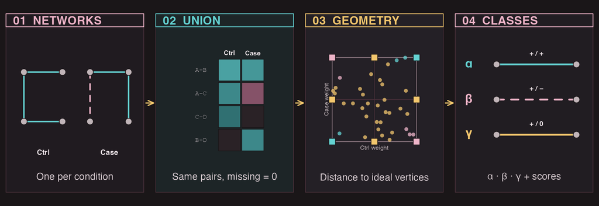

**Compare the same gene pairs:** **α** = present in all networks with the same sign; **β** = present in all networks with opposite signs; **γ** = present in some networks only. Here **three** networks: controls (112), patients off lithium (74), and on lithium (152). Lithium was not randomized: treat changes as candidates, not proof of rewiring.

## CoDiNA · Edge Classes

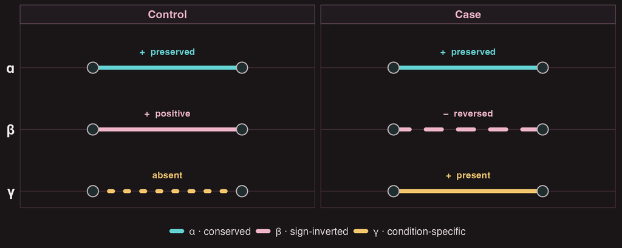

For two networks, **β edges** are often the most interesting: the same pair is co-expressed in both conditions, but the relationship **flips sign**.

## CoDiNA · The Method, Step by Step

**1 · Union.** Put all networks on the same set of pairs; a missing link gets weight 0. Optionally rescale with `stretch`.

**2 · Discretize.** Map each weight to $\{-1, 0, +1\}$ using `cutoff`, so every link becomes a vertex of the cube $[-1,1]^n$.

**3 · Classify.** $\Phi$ = α, β, or γ; $\tilde\Phi$ adds *where*, e.g. `g.Lithium` = γ present only in the lithium network.

**4 · Score.** Each link is a point $\mathbf{w}$ in $[-1,1]^n$:

- `Score_center` $=\|\mathbf{w}\|$: strength, distance from the origin
- `Score_internal` = distance to its ideal vertex
- `Score_ratio` = strength within $\tilde\Phi$ ÷ `Score_internal`

**5 · Prioritize.** High `Score_ratio` means a **strong, well-classified** link. `ClusterNodes()` then assigns genes to classes from their links.

## CoDiNA · Three Networks, One Cube

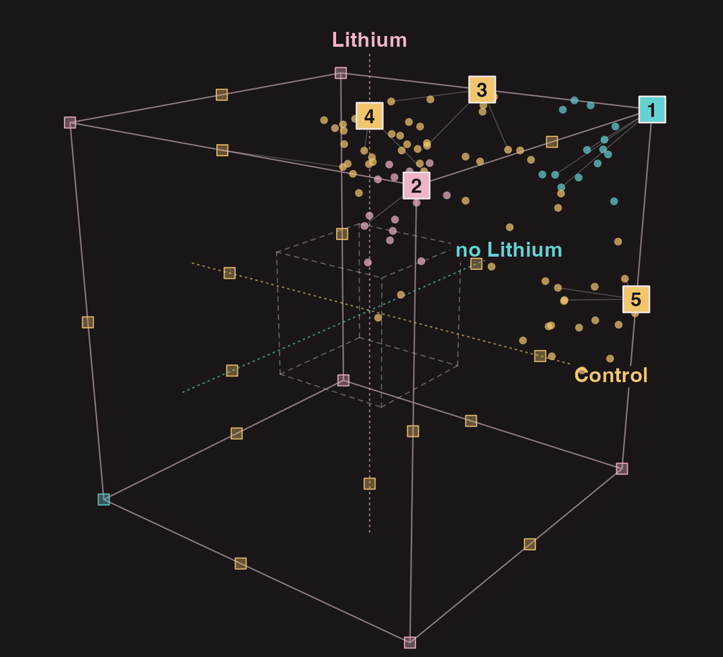

Each link has one weight per network, so with **three** networks it is a point $(w_{\text{Ctrl}}, w_{\text{off}}, w_{\text{on}})$ in the cube $[-1,1]^3$. Its class is the **nearest ideal corner**:

|  | Corner | Class | Reading |
| --- | --- | --- | --- |
| **1** | (+, +, +) | `a` | conserved |
| **2** | (+, −, +) | `b.noLithium` | sign flips off lithium |
| **3** | (0, +, +) | `g.noLithium.Lithium` | **disease** |
| **4** | (0, 0, +) | `g.Lithium` | **lithium only** |
| **5** | (+, +, 0) | `g.Control.noLithium` | **lost on lithium** |

26 corners: 2 α, 6 β, 18 γ. The dashed inner box is the cutoff: weights inside count as 0.

## CoDiNA · Run the Differential-Network Comparison

```r
to_codina_edges <- function(x, padj = 0.05) {   # keep stable links only
  x |> filter(pval.adj < padj) |> transmute(Node.1, Node.2, wTO)
}
codina_result <- CoDiNA::MakeDiffNet(
  Data = list(to_codina_edges(wto_control), to_codina_edges(wto_nolithium),
              to_codina_edges(wto_lithium)),
  Code = c("Control", "noLithium", "Lithium"), cutoff = 0.33,
  stretch = TRUE   # rescale each network by its max |wTO| (unequal group sizes)
)
sort(table(codina_result$Phi_tilde), decreasing = TRUE) |> as.data.frame() |>
  setNames(c("Phi_tilde", "links"))
```

```
            Phi_tilde  links
1                   a 484941
2   g.Control.Lithium 164255
3           g.Lithium 147171
4 g.noLithium.Lithium 112864
5         g.noLithium 111694
6           g.Control 101222
7 g.Control.noLithium  42568
8 b.noLithium.Lithium     16
9         b.noLithium      4
```

**Input:** the stable wTO links of each group (absent = 0). **Output:** one class per pair. **Why `stretch`:** groups of 112, 74 and 152 samples. Correlations from smaller groups are noisier and run larger in |value|, so without rescaling γ links pile up in the smallest group.

## CoDiNA · Every Real Link Is a Point in the Cube

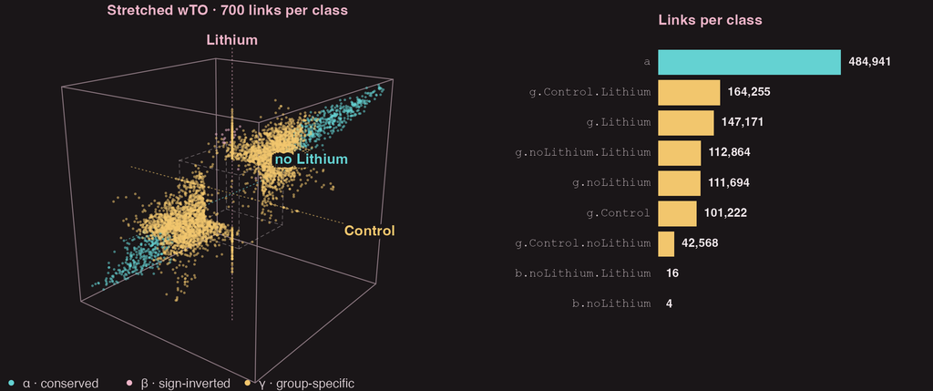

Each point is a real gene pair with its three stretched weights. Points cluster toward the corners that define their class; the bars count **every** link.

## CoDiNA · From Links to Genes

```r
codina_nodes <- CoDiNA::ClusterNodes(
  codina_result,
  cutoff.external = 0,   # keep links by Score_Phi_tilde
  cutoff.internal = 1    # and by Score_internal
)
gene_classes <- sort(table(codina_nodes$Phi_tilde),
                     decreasing = TRUE)
setNames(as.data.frame(gene_classes),
         c("Phi_tilde", "genes"))
```

```
            Phi_tilde genes
1                   a  1396
2   g.Control.Lithium   186
3           g.Lithium   168
4           g.Control    95
5         g.noLithium    94
6 g.noLithium.Lithium    57
7 g.Control.noLithium     4
```

Each gene inherits the classes of its links. `ClusterNodes()` keeps a class only when a **chi-square test** shows the gene’s links concentrate there (BH < 0.05); otherwise the gene is **U**.

**γ.noLithium.Lithium**: partners gained in **both** patient groups, the disease signature. **γ.Lithium**: only on lithium. **γ.Control.noLithium**: lost on lithium.

## CoDiNA · The Rewired Neighbourhood

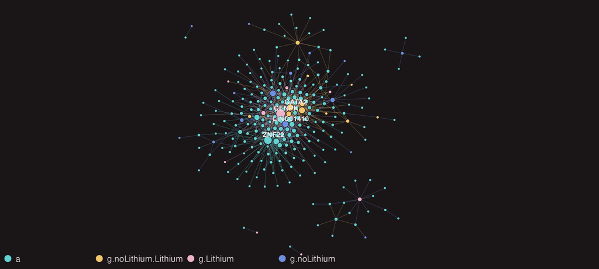

The 200 best-classified links (highest `Score_ratio`) of each of four classes. Node and link colour = class: conserved, disease, lithium only, and off-lithium only (blue). Labels mark the most connected gene of each class.

## CoDiNA · What Do the Disease and Lithium-only Genes Do?

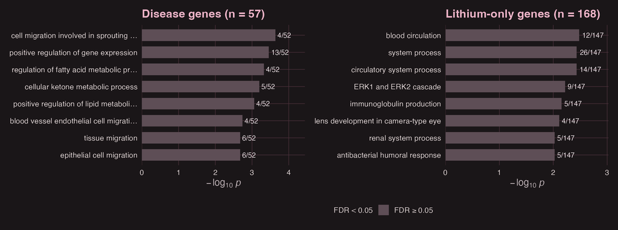

GO BP against the 2,000-gene universe: **0** terms pass FDR < 0.05 for the disease genes and **0** for the lithium-only genes. So we go from **what changed** (CoDiNA) to **which genes** (ClusterNodes) to **what they might do** (ORA, against the right universe).

## CoDiNA · Interpreting Edge Classes

| Class | Relationship across networks | Interpretation |
| --- | --- | --- |
| **α** | Present in all networks, same sign | Conserved candidate edge |
| **β** | Present in all, sign differs in some | Sign-inverted candidate edge |
| **γ** | Present in some networks only | Group-specific candidate edge |

These classes describe changes in **association**. They do not prove that a regulatory mechanism was rewired.

Prioritize links with high `Score_ratio`, then ask whether their genes cluster into a coherent, testable program.

## Hands-on · CoDiNA

**Exercises 9–10** · ≈ 10 min · hands-on notebook, section 9

9. Re-run `MakeDiffNet()` with `stretch = FALSE`. How do the γ classes shift, and why does group size matter?
10. Use `ClusterNodes()` to list the **disease** genes (γ.noLithium.Lithium) and the **lithium-only** genes (γ.Lithium).

## Answer · Exercise 9 · Why Stretch?

```r
nets3 <- list(control = wto_control, no_lithium = wto_nolithium,
              lithium = wto_lithium)
sapply(nets3, function(x) quantile(abs(x$wTO), c(0.5, 0.9, 0.99)))
##     control no_lithium lithium
## 50%   0.138      0.166   0.145
## 90%   0.311      0.341   0.308
## 99%   0.428      0.433   0.408
codina_raw <- suppressMessages(CoDiNA::MakeDiffNet(
  Data = lapply(nets3, to_codina_edges),
  Code = c("Control", "noLithium", "Lithium"),
  cutoff = 0.33, stretch = FALSE))
lv <- sort(unique(codina_result$Phi_tilde))
cbind(stretch = table(factor(codina_result$Phi_tilde, lv)),
      raw = table(factor(codina_raw$Phi_tilde, lv)))
##                     stretch   raw
## a                    484941 90802
## b.noLithium               4     0
## b.noLithium.Lithium      16     0
## g.Control            101222 24664
## g.Control.Lithium    164255 13639
## g.Control.noLithium   42568 22926
## g.Lithium            147171 13091
## g.noLithium          111694 87739
## g.noLithium.Lithium  112864 19994
```

The networks do not share one scale: the 74-patient network sits **highest** across its whole |wTO| distribution. On the raw scale, links cross 0.33 most often in that group, so γ links pile up in `g.noLithium` and the other classes shrink.

`stretch = TRUE` rescales each network by its own maximum |wTO| first. Group size is one reason for the different scales (fewer samples, noisier and larger |r|); real biology is another.

## Answer · Exercise 10 · Disease and Lithium-only Genes

```r
c(disease = length(disease_genes),
  lithium_only = length(case_genes))
##      disease lithium_only
##           57          168
head(sort(disease_genes), 8)
## [1] "ADISSP"    "ALDH2"     "ATP9A"     "BUB1"
## [5] "C14orf132" "CAPN12"    "CCN3"      "CD14"
head(sort(case_genes), 8)
## [1] "ABCG2"   "ADAM23"  "ADGRE1"  "AKAP12"  "ALOX15"
## [6] "ANGPT1"  "ANKDD1A" "ANKUB1"
```

**57** disease genes (`g.noLithium.Lithium`) and **168** lithium-only genes (`g.Lithium`).

Disease genes are connected in **both** patient groups but not in controls, so lithium cannot explain them. Lithium-only genes gain partners only in treated patients. A gene is classified only when a chi-square test says its links concentrate in one class; otherwise it is **U**.

## Network Change Is Not Differential Expression

| Analysis | What changes? | Typical result |
| --- | --- | --- |
| Differential expression (limma) | Mean expression by group | Ranked genes or DEGs |
| Co-expression network | Pairwise association structure | Modules and weighted edges |
| Differential network (CoDiNA) | Edge presence or sign across groups | Conserved or rewired candidates |

A gene can have a similar average expression in all groups while its relationships with other genes differ. A gene can be a DE hit, a network candidate, both, or neither. The lists are not supposed to agree: each method sees something the others miss.

## DE and Networks, Gene by Gene

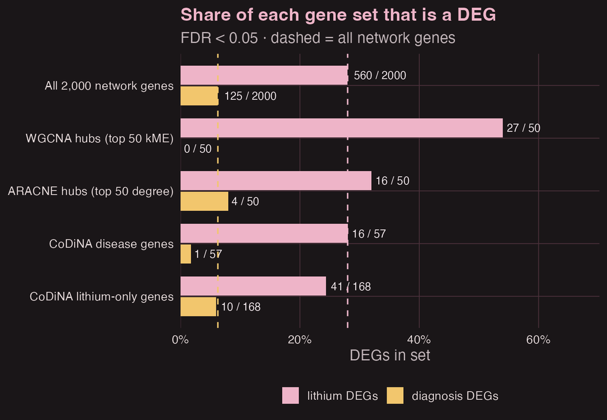

limma tested all 13,013 expressed genes. **4,958** differ between patients on and off lithium (**lithium DEGs**) and **495** between patients off lithium and controls (**diagnosis DEGs**), at FDR < 0.05. Only **560** and **125** of them are among the 2,000 network genes: in blood, the most **variable** genes differ between people (HLA genotype, cell mix), not between groups.

Bars **above** the dashed baseline concentrate DE signal; bars **below** it point at genes that DE alone would miss.

# Part V · From Structure to Function

ORA · GSEA

## What Can We Enrich?

**Gene sets from the network:**

- genes assigned to a WGCNA module
- intramodular hubs (high kME)
- hubs or neighborhoods from ARACNE or wTO
- genes in CoDiNA β or γ links

**Rankings from the network:**

- kME for one module
- node strength or centrality

**Annotation resources:**

- Gene Ontology (BP, CC, MF)
- KEGG, Reactome, WikiPathways
- MSigDB hallmarks and cell-type signatures

State the resource, its version, and the **background universe**. Here the universe is the 2,000 genes that could enter the network, not the whole genome.

## ORA · How It Works

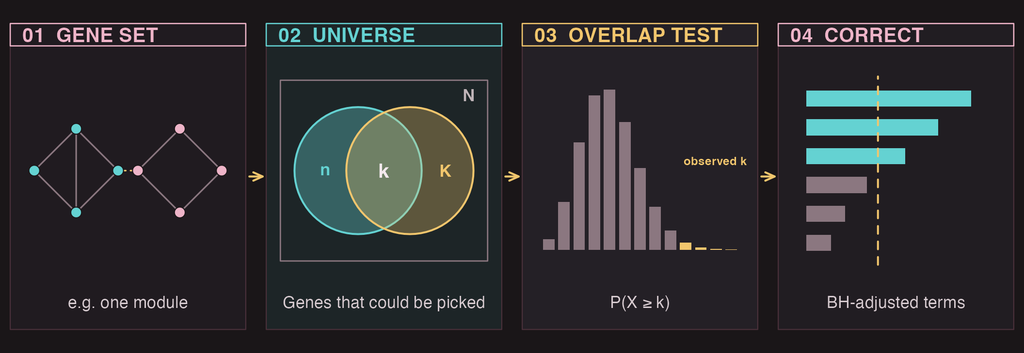

$$p=P(X\ge k)=\sum_{x=k}^{\min(n,K)}\frac{\binom{K}{x}\binom{N-K}{n-x}}{\binom{N}{n}}$$

$N$ universe genes, $K$ in the pathway, $n$ in the module, $k$ in both. A large $k$ relative to $nK/N$ means **over-representation**. Correct the p-values across all tested terms (Benjamini–Hochberg).

## GSEA · How It Works

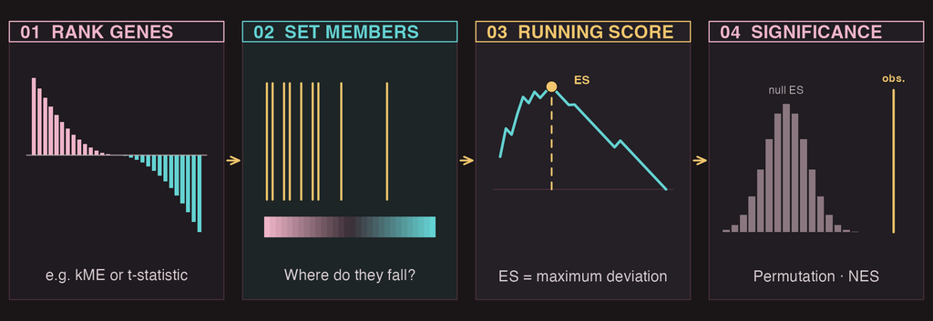

Walk down the ranking: the score **rises** at each set member (weighted by $|r_i|$) and **falls** otherwise. The enrichment score ES is the maximum deviation from zero. Permutations give its null distribution, and NES normalizes ES for set size. **No cutoff is needed.**

## ORA or GSEA?

| Method | Input | Best suited to | Main caveat |
| --- | --- | --- | --- |
| **ORA** | A selected gene list + universe | Testing a defined module or candidate set | Depends on the list cutoff and universe |
| **GSEA** | A ranked gene list | Detecting coordinated shifts across a ranking | Depends on a defensible ranking statistic |

Both require identifier mapping, an appropriate gene-set resource, and multiple-testing correction.

**Choose ORA** for a well-justified discrete set with an explicit universe. **Choose GSEA** when the full ranked statistic is meaningful. Neither method rescues a biased gene list or an inappropriate background.

## Example · GO Over-representation

```r
module_sizes <- sort(table(module_colors[module_colors != "grey"]), decreasing = TRUE)
selected_module <- names(module_sizes)[1]
module_genes <- names(module_colors[module_colors == selected_module])
to_entrez <- function(symbols) clusterProfiler::bitr(
  symbols, fromType = "SYMBOL", toType = "ENTREZID", OrgDb = org.Hs.eg.db::org.Hs.eg.db)
gene_map <- to_entrez(module_genes)
background_map <- to_entrez(selected_genes)          # universe = genes that entered the network
ora_result <- clusterProfiler::enrichGO(
  gene = unique(gene_map$ENTREZID), universe = unique(background_map$ENTREZID),
  OrgDb = org.Hs.eg.db::org.Hs.eg.db, keyType = "ENTREZID", ont = "BP",
  pAdjustMethod = "BH", pvalueCutoff = 1, qvalueCutoff = 1   # keep all; filter on FDR below
)
c(module = selected_module, genes = length(module_genes),
  significant_terms = sum(as.data.frame(ora_result)$p.adjust < 0.05))
```

```
           module             genes significant_terms
      "turquoise"             "426"              "93"
```

## ORA · Reading the Result

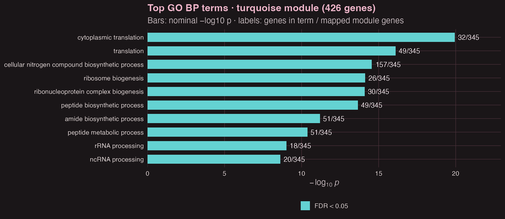

Here, **93 terms** pass FDR < 0.05 against the 2,000-gene universe. A whole-genome background can inflate enrichment for pathways that were more likely to enter the gene set in the first place. Always test against the genes that **could** have been selected.

## Example · GO Gene Set Enrichment Analysis

```r
kme_column <- paste0("kME", sub("^ME", "", selected_module))
gene_rank <- sort(setNames(kme_matrix[, kme_column], rownames(kme_matrix)), decreasing = TRUE)
rank_map <- to_entrez(names(gene_rank))
rank_table <- data.frame(SYMBOL = names(gene_rank), score = as.numeric(gene_rank)) |>
  inner_join(rank_map, by = "SYMBOL") |>
  distinct(ENTREZID, .keep_all = TRUE)
gene_rank_entrez <- sort(setNames(rank_table$score, rank_table$ENTREZID), decreasing = TRUE)

gsea_result <- clusterProfiler::gseGO(
  geneList = gene_rank_entrez, OrgDb = org.Hs.eg.db::org.Hs.eg.db,
  ont = "BP", keyType = "ENTREZID", pAdjustMethod = "BH",
  pvalueCutoff = 0.05, seed = TRUE
)
nrow(as.data.frame(gsea_result))
```

```
[1] 277
```

Genes are ranked by **module membership (kME)** for the turquoise module. GSEA asks which pathways concentrate among the module’s most central genes, without choosing a cutoff.

## GSEA · Reading the Result

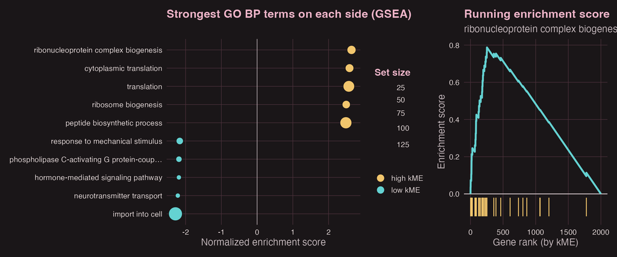

**Positive NES:** the pathway concentrates among the module’s most central genes (high kME). **Negative NES:** among the genes least connected to it. Gold ticks mark set members along the ranking.

## Hands-on · Enrichment

**Exercises 11–13** · ≈ 15 min · hands-on notebook, sections 10–11

11. ORA on the γ.Lithium genes with the 2,000-gene universe vs the whole genome: how many terms pass FDR in each?
12. Rank all genes by kME of the trait-associated module and run GSEA. Which terms have the largest NES?
13. Flag each network gene as DEG, WGCNA hub, ARACNE hub, or CoDiNA class. Which genes do DE and networks agree on?

## Answer · Exercise 11 · The Background Matters

```r
ids <- function(g) unique(to_entrez(g)$ENTREZID)
ora_bg <- function(genes, universe = NULL)
  clusterProfiler::enrichGO(
    gene = ids(genes),
    universe = if (!is.null(universe)) ids(universe),
    OrgDb = org.Hs.eg.db::org.Hs.eg.db,
    keyType = "ENTREZID", ont = "BP", pAdjustMethod = "BH",
    pvalueCutoff = 1, qvalueCutoff = 1)
n_terms <- function(x)
  if (is.null(x)) 0 else sum(as.data.frame(x)$p.adjust < 0.05)
ora_counts <- c(
  network_universe = n_terms(ora_bg(case_genes, selected_genes)),
  whole_genome = n_terms(ora_bg(case_genes)))
ora_counts
## network_universe     whole_genome
##                0                0
```

**0** terms pass FDR < 0.05 against the 2,000 network genes and **0** against the whole genome.

The two runs ask different questions: are the lithium-only genes special **among variable blood genes**, or **among all annotated genes**? Terms can appear or disappear in either direction. Whichever background you choose, report it.

## Answer · Exercise 12 · GSEA on Module Membership

```r
rank_tbl <- tibble(SYMBOL = names(kme_top), score = kme_top) |>
  inner_join(to_entrez(names(kme_top)), by = "SYMBOL") |>
  distinct(ENTREZID, .keep_all = TRUE)
ranks <- sort(setNames(rank_tbl$score, rank_tbl$ENTREZID), decreasing = TRUE)
gsea_trait <- clusterProfiler::gseGO(
  ranks, OrgDb = org.Hs.eg.db::org.Hs.eg.db, ont = "BP",
  keyType = "ENTREZID", pvalueCutoff = 0.05, seed = TRUE, verbose = FALSE)
as.data.frame(gsea_trait) |> arrange(desc(NES)) |> head(5) |>
  transmute(term = trunc_txt(Description, 45), setSize,
            NES = round(NES, 2), padj = signif(p.adjust, 2))
##                                          term setSize  NES    padj
## GO:0009755 hormone-mediated signaling pathway      15 2.11 3.3e-03
## GO:0001659            temperature homeostasis      27 2.10 1.2e-03
## GO:0098657                   import into cell     131 2.07 3.7e-05
## GO:0030029       actin filament-based process      99 2.06 1.3e-04
## GO:1990845             adaptive thermogenesis      23 2.04 4.0e-03
```

Genes are ranked by kME for the black module. A positive NES means the term is concentrated among the genes most tied to the module; no cutoff was needed. Compare these terms with the hubs from Exercise 5.

## Answer · Exercise 13 · Do DE and Networks Agree?

```r
wgcna_hubs <- names(head(sort(kme_top[module_colors == top_color],
                              decreasing = TRUE), 50))
flags <- tibble(gene = selected_genes) |>
  mutate(DEG = gene %in% deg_genes,
         WGCNA_hub = gene %in% wgcna_hubs,
         ARACNE_hub = gene %in% aracne_hubs,
         CoDiNA_lithium = gene %in% case_genes,
         network = WGCNA_hub | ARACNE_hub | CoDiNA_lithium)
with(flags, table(DEG, network))
##        network
## DEG     FALSE TRUE
##   FALSE  1258  182
##   TRUE    479   81
c(disease_genes = length(disease_genes),
  also_diagnosis_DEG = sum(disease_genes %in% dx_genes))
##      disease_genes also_diagnosis_DEG
##                 57                  1
```

**81** genes are flagged by both DE and a network method; **182** only by a network method. Of the 57 disease genes, 1 are diagnosis DEGs.

The methods answer different questions, so the lists overlap only partly. Genes found by **both** are the strongest candidates; network-only genes are where co-expression adds something DE cannot see.

# Part VI · Wrap-up

Compare · reflect · reproduce

## Comparing the Network Methods

| Method | Edge score | Main output | Strength | Limitation |
| --- | --- | --- | --- | --- |
| **WGCNA** | Correlation$^\beta$, TOM | Modules, eigengenes, kME | Modular organization, trait links | Keeps indirect edges; unsigned by default |
| **ARACNE** | Mutual information + DPI | Sparse network | Nonlinear; prunes indirect links | Needs many samples |
| **wTO** | Signed correlation + neighbors | Signed edges with p-values | Sign-aware, resampling-based | Resampling is costly |
| **Consensus** | Weighted mean of wTO | Robust edges | Reproducibility across cohorts | Needs comparable datasets |
| **CoDiNA** | Geometry across networks | α, β, γ classes + scores | Condition differences | Inherits input-network quality |

## Parameter Sensitivity and Methodological Care

| Choice to perturb | What to compare |
| --- | --- |
| WGCNA `power`, `minModuleSize`, `mergeCutHeight` | Module assignments and phenotype associations |
| ARACNE estimator and `eps` | Edge weights and network density |
| wTO resampling method, `n`, and edge threshold | Edge stability and network density |
| CoDiNA `cutoff` and `stretch` | α, β, and γ classifications |
| Enrichment universe, database, and ID mapping | Terms, FDR, and leading genes |

Define the background gene universe, correct for multiple testing, report unmapped IDs, and validate prioritized findings in an independent cohort when possible.

## Limitations and Common Pitfalls

1. Correlation does not imply causation or physical interaction.
2. Few samples per condition make individual edges uncertain.
3. Gene-ID mapping can reduce the coverage of functional analyses.
4. Network and enrichment results depend on thresholds and databases.
5. Candidate modules and edges need independent or experimental validation.

Everything we built today generates **hypotheses**. None of it is a finding until it holds up in an independent cohort.

## The Full Route, Once More

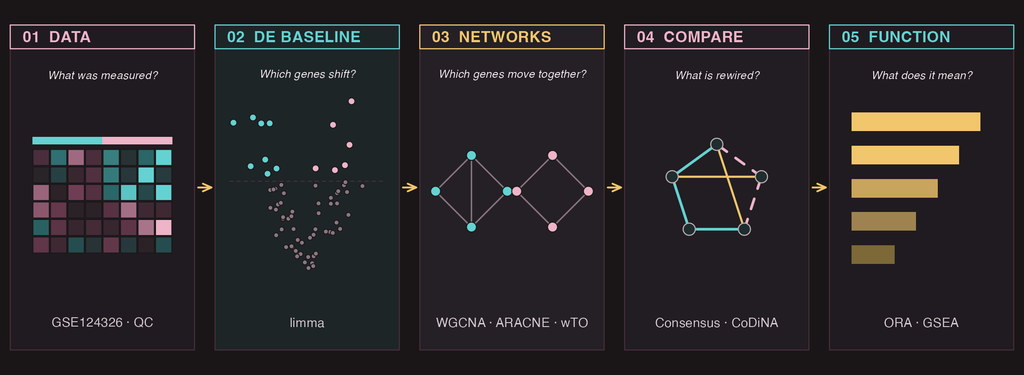

Each stop answers a different question. Together they turn a matrix of numbers into a **short list of genes you can test**.

## Conclusion

Back to lithium and bipolar disorder:

1. In blood, the loudest co-expression comes from **people, plates, and cell mix**. Adjust and filter before building anything.
2. Lithium shifts thousands of genes, each by a little, and part of its signal travels with neutrophil counts. It was not randomized, so it stays a hypothesis.
3. With three groups, CoDiNA separates links shared by **all patients** (disease) from links seen **only on lithium** (drug). Set next to the DEGs, they show what co-expression adds.
4. WGCNA, ARACNE, and wTO define a link differently; consensus asks what is **robust**, CoDiNA what **changed**, and ORA and GSEA what it might mean, given a stated universe.
5. Report every parameter, and validate before claiming mechanism.

## From Bulk to Single Cells

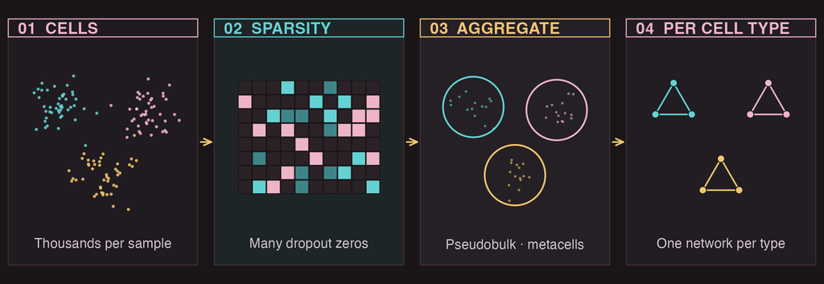

**The challenge:** single-cell matrices are sparse, and correlations across cells mix **cell-type composition** with true co-regulation.

**The strategy:** aggregate first (**pseudobulk** per sample and cell type, or **metacells** as in hdWGCNA), then apply today’s methods **within** each cell type.

## Where to Go Next

### Go deeper

- **WGCNA tutorials** · consensus modules across datasets, module preservation
- **wTO** and **CoDiNA** vignettes · more than two networks, interactive plots
- **hdWGCNA** · co-expression for single-cell and spatial data
- **SCENIC** · regulatory networks from single cells

### Share and explore

- Export to **Cytoscape**: `igraph::write_graph(g, "net.graphml", "graphml")` or `RCy3`
- Network medicine workshop: https://deisygysi.github.io/NetMed_Workshop/
- Today’s hands-on notebook and the cached networks in `results/`

Start from a question, choose the definition of a link that matches it, and report every choice.

## References

- Aibar, S. et al. (2017). SCENIC: single-cell regulatory network inference and clustering. *Nat Methods*, 14, 1083–1086.
- Barabási, A.-L. & Albert, R. (1999). Emergence of scaling in random networks. *Science*, 286, 509–512.
- Barabási, A.-L. & Oltvai, Z. N. (2004). Network biology: understanding the cell’s functional organization. *Nat Rev Genet*, 5, 101–113.
- Gysi, D. M. et al. (2018). wTO: an R package for computing weighted topological overlap and consensus networks. *BMC Bioinformatics*, 19, 392.
- Gysi, D. M. et al. (2020). Whole transcriptomic network analysis using Co-expression Differential Network Analysis (CoDiNA). *PLOS ONE*, 15(10), e0240523.
- Krebs, C. E. et al. (2020). Whole blood transcriptome analysis in bipolar disorder reveals strong lithium effect. *Psychol Med*, 50, 2575–2586.
- Langfelder, P. & Horvath, S. (2008). WGCNA: an R package for weighted correlation network analysis. *BMC Bioinformatics*, 9, 559.
- Margolin, A. A. et al. (2006). ARACNE: an algorithm for the reconstruction of gene regulatory networks. *BMC Bioinformatics*, 7(Suppl 1), S7.
- Meyer, P. E., Lafitte, F. & Bontempi, G. (2008). minet: an R/Bioconductor package for inferring large transcriptional networks using mutual information. *BMC Bioinformatics*, 9, 461.
- Morabito, S. et al. (2023). hdWGCNA identifies co-expression networks in high-dimensional transcriptomics data. *Cell Rep Methods*, 3, 100498.
- Newman, M. E. J. (2006). Modularity and community structure in networks. *PNAS*, 103, 8577–8582.
- Nowick, K. et al. (2009). Differences in human and chimpanzee gene expression patterns define an evolving network of transcription factors in brain. *PNAS*, 106, 22358–22363.
- Smyth, G. K. (2004). Linear models and empirical Bayes methods for assessing differential expression in microarray experiments. *Stat Appl Genet Mol Biol*, 3, Article 3.
- Subramanian, A. et al. (2005). Gene set enrichment analysis. *PNAS*, 102, 15545–15550.
- Yu, G. et al. (2012). clusterProfiler: an R package for comparing biological themes among gene clusters. *OMICS*, 16(5), 284–287.
- Zhang, B. & Horvath, S. (2005). A general framework for weighted gene co-expression network analysis. *Stat Appl Genet Mol Biol*, 4, Article 17.

## Thank You

### Co-expression Networks: Construction and Analysis

**Dr. Deisy Morselli Gysi**  
Federal University of Paraná (UFPR), Brazil

deisy.gysi@ufpr.br · https://deisygysi.github.io/

ISCB Latin America SoIBio SPBBC Conference on Bioinformatics 2026  
November 9, 2026

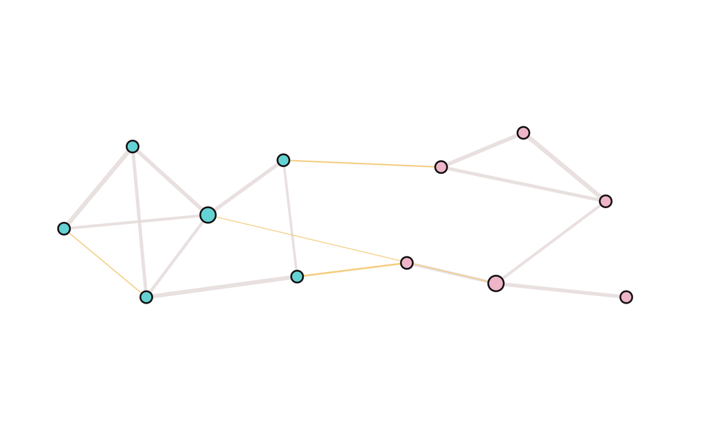

Organized by the Sociedad Peruana de Bioinformática y Biología Computacional (SPBBC), the Iberoamerican Society of Bioinformatics (SoIBio), and the International Society for Computational Biology (ISCB).